# Capstone Project : Word Prediction Model

Jacob Paracka

March 16, 2018

## Introduction

- The objective of the project is to build a word prediction model that will aid typing by predicting the most probable next words based on the previous words/phrases entered. This is the final delivery for Coursera’s Data Science Specialization: Swiftkey Capstone Project
- The prediction model is developed based on a data set consisting of blogs, news articles and tweets
- A web based application is developed (Shiny io), that reads an input from the user that uses the model to predict the three most probable next words.
- The application is designed to enable users to easily select the predicted words and complete the sentence
- Special emphasis is made to tune the model for optimum memory utilization and accuracy. Some trade-offs are mode so that the application is light and fast.

## Model building - Highlights

The model if built from a samples of 200,000 blogs, news and tweets each. The sample size was selected to get as much data which could be processed in a reasonable time period.

Step 1 Data Cleaning and preprocessing

- remove all punctuations
- conver to all lower case
- remove special characters and empty space
- remove profanity

Step2 Building NGrams

- use the quanteda package to build NGrams with lengths 1 to 6
- get the count of each NGram in the data and arrange them by frequency

Step3: Algorithm

- The last N-1 words from the input is matched with the initial N-1 words in the NGram. If a match is found , the last word in the NGram is the prediction. The frequency of that NGram is the weightage of the prediction
- The matching is done starting from the 6Grams to the 2Grams. Matches from longer NGrams are given higher weightage
- Next word prediction is triggered when the user inputs a space, indicating the end of the previous word. While a word is being typed, the application looks up the uni-gram for suggestions of the current word.

# Model Performance Tuining

Using NGrams of lenghts 6 and 5 proved to use high memory andn was not very responsive. Also noticed that a large part of these Ngrams were single occurances. Exploratory analysis showed that theses are a result of errors in spelling or incorrect usage of words.

Possible tuining approaches

- Change number of NGrams used in prediction
- Optimize single occurance NGams (the long tail)

A preformance measurement for the prediction was done with various combination of NGrams. The results are below.

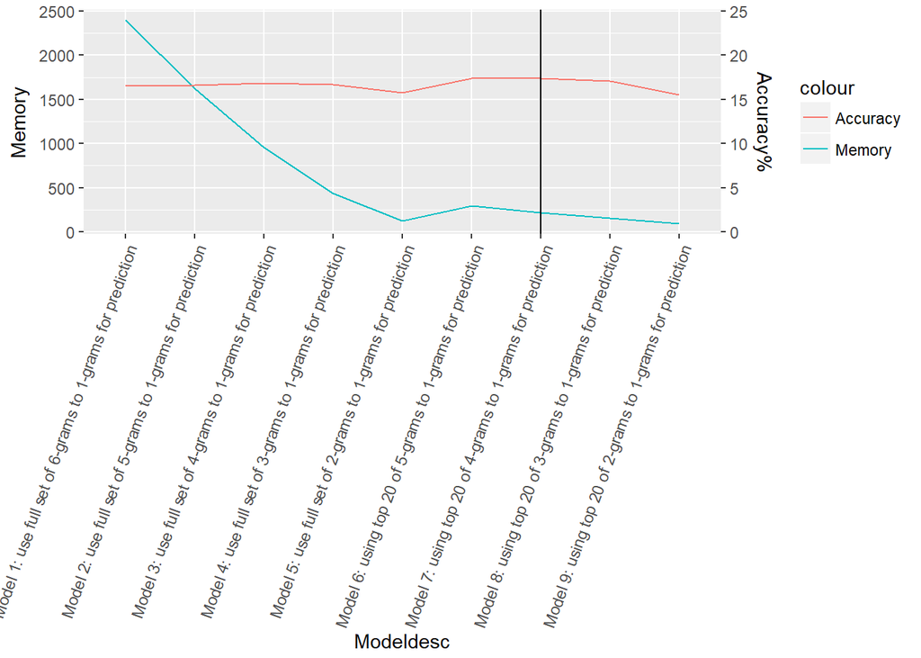

In favor of performance the following changes were made to the model - user only QuadGram, TriGram and BiGrams for prediction - For each N-1 group of words, use only the top 20 rows in the NGrams. - Remove Single occurance NGrams The prediction accuracy was not impacted by these changes.

# Word Predition Application

The application is designed to take the user input and provides the top 3 predictions. User can select the predicted words by clicking on the corresponding buttons. Thus reducing the number of key strokes needed to complete the sentence. Application also has a current word predictions capability based on a partial word input A word cloud of the top 2- predictions is also displayed as suggestions beyond the top3

# Conclusion

- Using a small data set and a simple algorithm a relatively good prediction model could be developed.
- The shiny framework provides and very easy way to build applications
- This project was definitely a great hands on experience in data science.